# Mortgage structure, saving rates and the wealth distribution

Luís Teles Morais

Erasmus University Rotterdam (visiting SAFE)

**Goethe University Finance Brown Bag**  
Frankfurt am Main, 18 November 2026

# Introduction

## How do **fixed repayment schedules** in mortgages affect saving and wealth?

Mortgage **debt repayments** are a large fraction of household *saving* flows

- Housing main asset on wealth portfolios (*stock*)
- But also in *flows*: $\sim 30\%$ of Euro area aggregate saving (similar in US)

Mortgages often mandate **fixed repayment schedules** e.g. annuity loans Amortizing vs. IO

- Fixed at origination; deviating is costly (refinancing, late penalties, …)

New homeowners are highly constrained: **hand-to-mouth**, high debt and expected income growth

- Average recent homebuyer in the Euro area: liquid wealth $= 17.5\%$ of annual income

**This paper:** **fixed repayments increase overall saving ($\downarrow C$), but crowd out *liquid* saving**

- Reduced consumption smoothing, increase share of hand-to-mouth
- Effects concentrated at bottom of income and wealth distributions

## This paper: model + data

#### Life-cycle model with costly deviation from repayment schedule

- Homeowners face uninsurable income risk, optimize saving and repayment over mortgage lifecycle
- HFCS data on Netherlands policy that increased cost of deviation for new homebuyers, via tax incentives

#### Model matches life-cycle moments of liquid wealth and mortgage debt and reveals effects of fixed repayments

- Pre-policy, full life-cycle data identifies preferences; post-policy behavior identifies repayment friction
- Policy equivalent to imposing a $67\%$ premium on under-payment

#### Main results from applying pre-reform repayment rules to post-reform buyers in the model

- **1.** Homeowners save more, reducing consumption by $10\%$ of income, but are more exposed to shocks
- **2.** $\uparrow$ Total wealth/income, but $\downarrow$ liquid wealth $\Rightarrow$ **15 p.p. $\uparrow$ $\%$ HtM**  
  Mean liquid wealth $\downarrow$ $24\%$ $\rightarrow$ $19\%$ of annual income
  - Effects stronger at the bottom: $\downarrow$ wealth inequality but $\uparrow$ financial wealth inequality
- **3.** Restriction to consumption smoothing very costly: equivalent to $\approx$ **2-3%** of lifetime $C$

## Contribution

Paper fits in literature modelling life-cycle and welfare effects of mortgage structure  
Boar et al. (2022), Backman et al. (2025), Balke et al. (2024), Boutros et al. (2025), Ferreira et al. (2024), Gete & Zecchetto (2018, 2024), Greenwald et al. (2018), Karlman et al. (2021), Vestman (2018)

- Effects of amortization requirements on household consumption and saving  
  Andersen et al. (2021); Backman & Khorunzhina (2024); Backman et al. (2024); Bernstein & Koudijs (2024), Larsen et al. (2024)
  - This paper: crowding out of liquid wealth; long-run/life-cycle effects
- Wealth distribution and the high share of “wealthy hand-to-mouth”  
  Aguiar, Bils & Boar (2025), Boar, Gorea & Midrigan (2022), Kaplan & Violante (2014)
  - This paper: evidence of clear mechanism driving up WHtM share
- Optimal mortgage contract structure  
  Campbell and Cocco (2015), Campbell et al. (2018), Chambers et al. (2009), Gete (2018), Guren et al. (2018), Piskorski & Tchistyi (2010, 2011)
  - This paper: (heterogeneous) effects on household wealth and welfare of repayment rigidity

## Agenda

1. Introduction
2. Model framework
3. Data: stylized facts and calibration
4. Model results
5. Conclusion

# Model framework

## Model framework

### Overview

#### Life-cycle model of consumption and saving

- First‐time homebuyer life‐cycle, from origination to mortgage maturity
- Two assets: **liquid safe asset** (risk‐free) vs. **mortgage debt**; housing fixed
- Idiosyncratic income risk (permanent + transitory)
- Realistic mortgages with repayment transaction costs, including the cost of deferring principal
  - How does this wedge affect saving and wealth accumulation?

## Model framework

### Household life cycle endowments and decisions

- A home worth $P_{0}$ (normalized) and a 30‐year fixed‐rate mortgage with balance $M_{0}$
- Initial financial wealth $A_{0}$ and exogenous risky earnings $Y_{t}$ over the life cycle
- Each period, choose consumption $c_t$ and mortgage repayment $d_t$

Utility from non‐housing consumption only ($H$ fixed):

$$U(c_{t}) = \frac{c_{t}^{\,1-\gamma}}{1 - \gamma}$$

- Separable preferences, so $\text{argmax} \sum_t u(C_t) = \text{argmax} \sum_t u(C_t, \bar{H})$ (Campbell-Cocco 2015)

## Model framework

### Assets & mortgage frictions

#### Liquid saving and mortgage debt

- Savings in the liquid asset ($a_{t}$) earn risk‐free interest $r$
- Borrowing constraints:
  - $a_{t} \ge \theta^a\,$ unsecured debt allowed and costly, paying $r^{-}$
  - Household cannot increase mortgage debt, only repay or maintain balance $\,d_{t} \ge 0\,$
- Outstanding mortgage debt demands interest with a positive spread $r^m > r$

#### Mortgage repayment schedule

- Mandatory amortization: $D^{*}(m_{t-1},\,t)$ from standard annuity formula
  - Deviating from repayment schedule $d_t < d_t^*$, then incurs transaction cost $\tau_t ≥ 0$
- If default, lose house and keep low consumption $\underline{c}$ until end

## Model framework

### Full dynamic household problem

The household solves, choosing consumption $c_t$ and repayment $d_t$:

$$V(t, s_t) = \max_{\{c_k, d_k\}_{k=t}^{T}} \; \mathbb{E}_t \left[ \sum_{k=t}^{T-1} \beta^{k-t} \frac{c_k^{1 - \gamma}}{1 - \gamma} + \beta^{T - t} B(a_T - m_T) \right], \; \textrm{s.t.}$$

$$\begin{aligned}
a_{t+1} &= (1 + r)\bigl[a_t + y_t - (r + s)m_t - d_t - \tau_t - c_t\bigr], \\
\quad m_{t+1} &= m_t - d_t \\
\tau_t &= \tau \cdot \max\{0, d_t^* - d_t\}, \quad a_t \ge \theta^a, \quad m_t \ge 0, \quad d_t \ge 0
\end{aligned}$$

- Terminal condition: bequest motive $B(a_T - m_T) = b_0 \frac{(a_T - m_T + b_1)^{\,1-\gamma}}{1-\gamma}$
- Full mortgage repayment by retirement, with any remaining liquid wealth left as a bequest
- Solved via deep-learning algorithm (Duarte et al. 2022; Barrera & de Silva 2024)

# Data: stylized facts and calibration strategy

## Data from the Netherlands and calibration strategy

#### HFCS: harmonized Euro-area survey, three waves (2013-21)

- Detailed household balance sheets, income, consumption, and **mortgages**

#### A 2013 reform raised the cost of repayment flexibility for new buyers

- Before 2013: flexible repayment, large interest-only at no extra cost
  - Median HH amortizes ~10% of income in EA, 2.5% in NL Amortization histograms
- From 2013: interest deduction restricted to the **conforming** part
  - Eliminating the rebate $\approx$ $\uparrow$ 2x cost of carrying non-conforming debt

## Initial conditions and calibration by purchase cohort

- Households simulated by drawing from the empirical joint distribution among **recent homebuyers**
- Composition stable; some drop in **interest rates** and **house prices**:

| Time of purchase | Pre-2013 | Post-2013 |
| --- | --- | --- |
| LTV at origination | 1.05 | 1.00 |
| Liquid wealth / income | -0.13 | 0.31 |
| Age at purchase | 32.14 | 32.95 |
| House price / income | 4.63 | 3.59 |
| Mortgage interest rate (%) | 4.56 | 2.36 |
| High education (%) | 69.15 | 73.59 |

- Reduced selection concerns; model allows to account for differences at purchase

#### What identifies preferences and repayment costs

- Pre-2013 buyers (free flexibility) → full life-cycle identifies preferences ($\beta$, $b_0$, $\tau^{pre}$)
- Post-2013 buyers (costly) → change in early amortization identifies the friction $\tau^{post}$
- Liquid wealth of post-2013 buyers **not targeted** → model reproduces observed crowd-out (validation)

## Cohort of post-2013 homebuyers subject to policy is repaying faster

#### Outstanding loan balance over time since origination

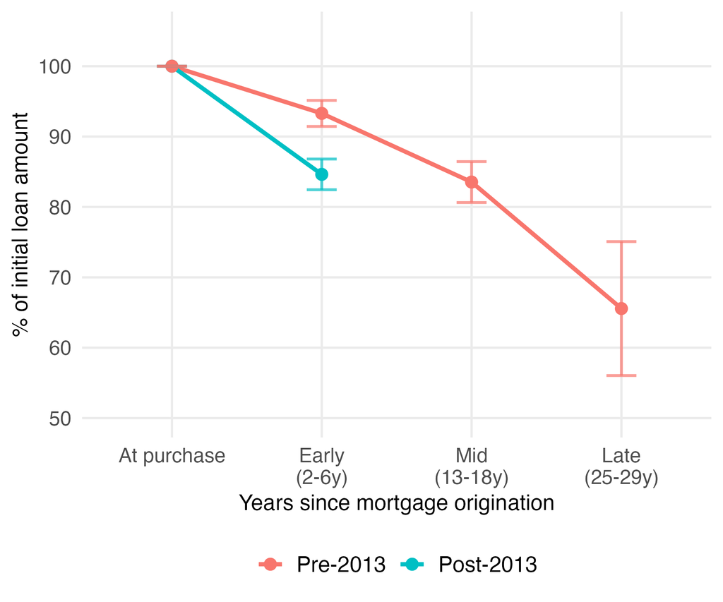

## Cohort of post-2013 homebuyers is building less liquid wealth

#### Liquid wealth over time since origination

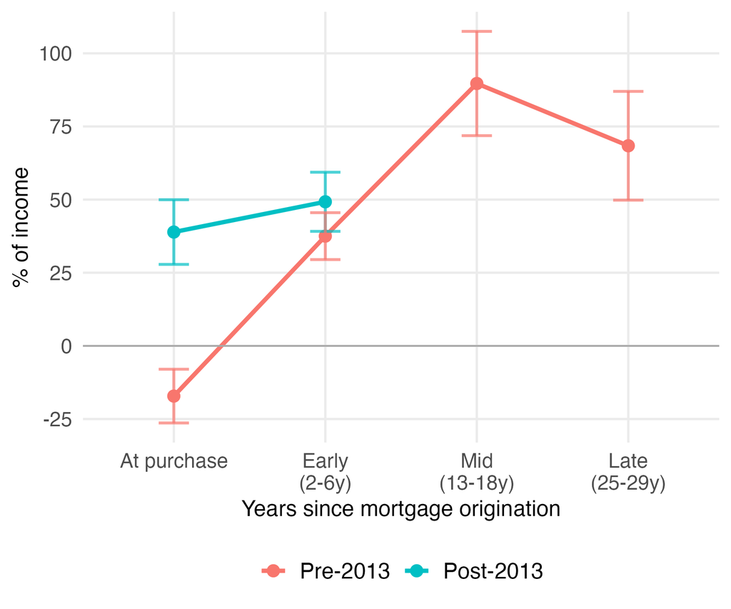

## Calibration

### Externally calibrated parameters

- Income process: Moments of stochastic process from NL micro data (de Nardi et al. 2021) Income process
  - Two permanent income types: college vs. lower education
- Other parameters:

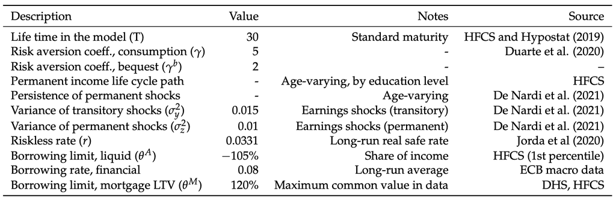

# Model results

## Debt repayment in the model and survey

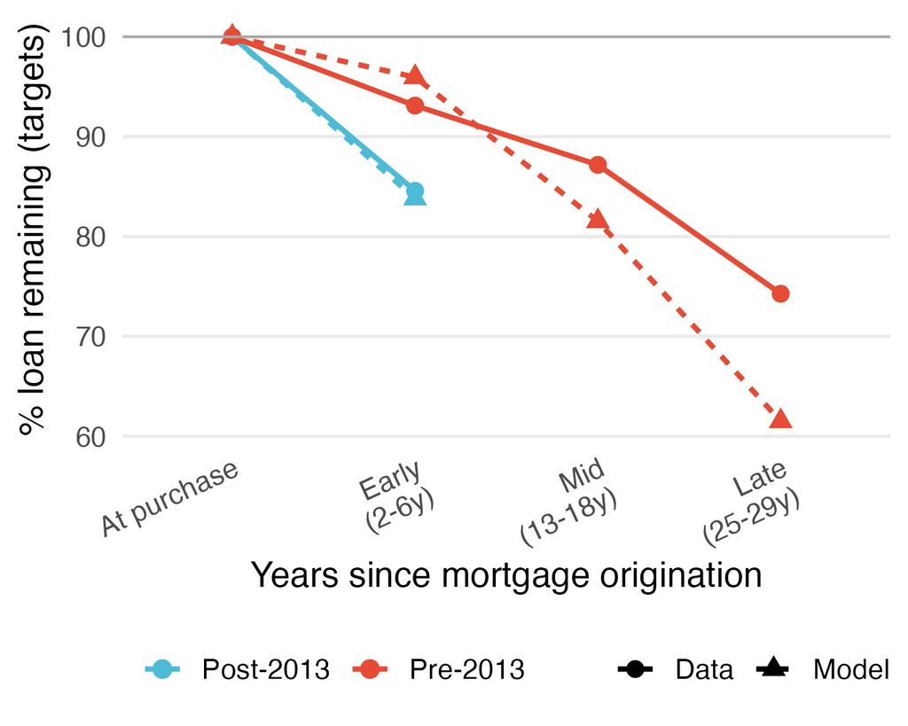

- Post-2013, higher penalty leads to faster early repayment (even with lower int. rates)

## Early post-reform liquid wealth in the model and survey

- Early post-reform liquid wealth: **42.7%** of annual income in the survey, **43.0%** in the model

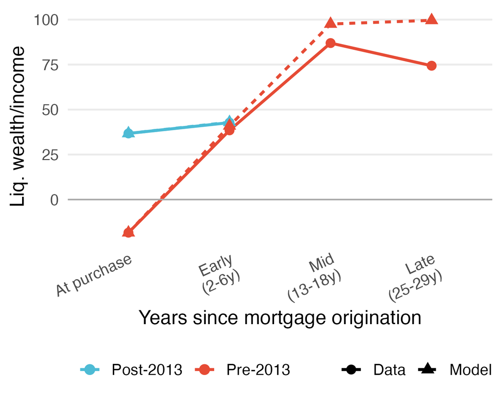

## Estimated parameters

- Simulated method of moments (SMM), matching model moments to the Dutch HFCS

| $\beta$ | **0.987** | Annual patience |
| --- | --- | --- |
| $b_0$ | **3.9** | Value of liquid wealth post-retirement |
| $\tau^{pre}$ | **0.01** | Cost of delayed repayment pre-policy (small) |
| $\tau^{post}$ | **0.665** | Large penalty post-policy |

**$\Delta\tau \approx 0.66$**: effect of policy restricting repayment flexibility

- Reflects tax penalty and potential changes in bank products
- Large enough to overcome the low-rate boost (post-2013 rates fell below liquid returns)
- Identified by sharp increase in early-stage repayment

## Income-poorer model HHs save more in total, but less into liquid wealth

#### Means of model population across income quintiles (conditional on age)

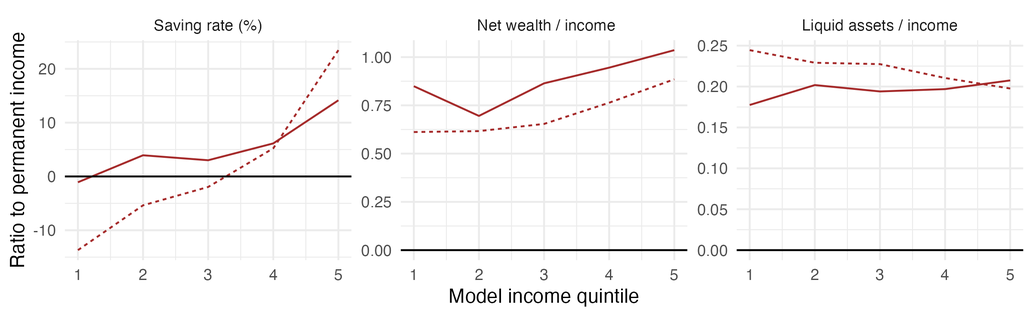

Costly deferral Flexible repayment

- Saving rate increases, but $\downarrow$ $C$, liquid savings $\Rightarrow$ More exposed to shocks
- Matches saving rate differences in the data Saving rate differences: model vs. data

## Costly underpayment raises hand-to-mouth incidence

#### Model counterfactuals for the same buyers

- Hand-to-mouth (HtM) defined as liquid wealth below one month of income

| Outcome | Flexible repayment | Costly underpayment |
| --- | --- | --- |
| Mean liquid wealth / annual income | 24% | 19% |
| Hand-to-mouth share | **4%** | **19%** |

#### By income quintile

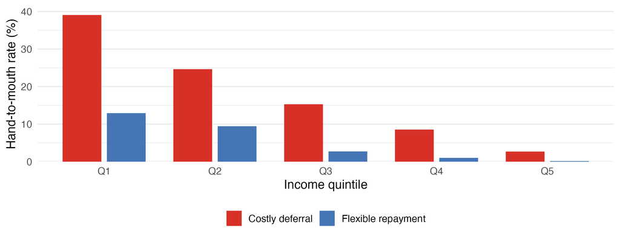

## Welfare costs of mandatory amortization

#### Median consumption-equivalent loss

| Simulated buyers | Median loss |
| --- | --- |
| All buyers | **2.41%** |
| Lower education | 2.82% |
| Higher education | 2.13% |

- Permanent consumption increase needed to offset the welfare loss
- Same homeowners, house prices and mortgage rates under both contracts

## Forced amortization increases saving rates at the bottom of wealth dist.

### Implying effects on distribution of total and financial wealth

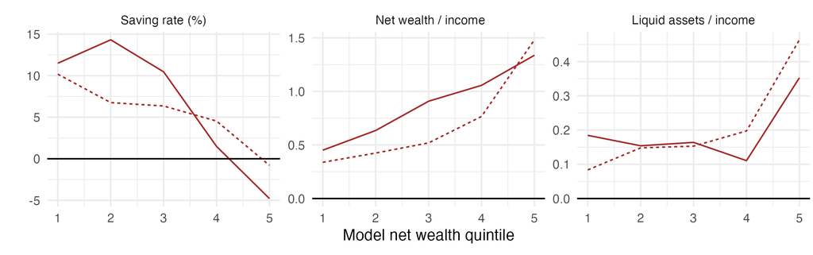

Costly deferral Flexible repayment

- Saving rates increase for groups at the bottom wealth groups
- Implications for wealth distribution: $\downarrow$ total wealth inequality but $\uparrow$ financial w. ineq., $\% HtM$

# Conclusion

## Conclusion

- Mortgage debt repayment is an important part of household saving flows (30$\%$ in Euro area)
- This paper: fixed repayment schedules crowd out liquid saving, limiting consumption smoothing
- Imposing amortization, through a $67\%$ penalty on delayed repayment (Netherlands), leads to:
  - Mean liquid wealth $\downarrow$ $24\%$ $\rightarrow$ $19\%$ of annual income
  - Share of hand-to-mouth $\uparrow$ $4\%$ $\rightarrow$ $19\%$
  - Welfare loss $\approx$ $2–3\%$ of lifetime consumption ($\approx$ one extra working year)
- Distributional implications: $\downarrow$ inequality in net worth, but $\uparrow$ in liquid financial wealth
  - Micro-foundation for large share of “wealthy hand-to-mouth”
- Amortization requirements may have financial stability benefits, but carry large costs for homeowners
  - Younger, lower-income households seem to be excessively penalized by rigid structure
  - Some flexibility can go a long way (optimal level for future work!)

**Thank you!**

Reach out: **luistelesm.github.io** | **luis.teles.m@novasbe.pt**

# Appendix

## Appendix

### What is an interest-only mortgage?

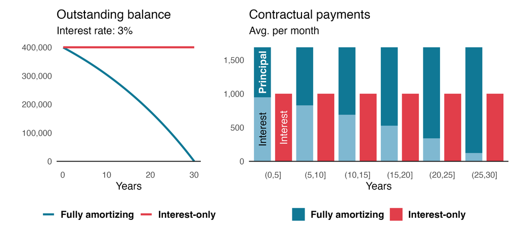

Back to main

## Appendix

### Hand-to-mouth incidence by income quintile

- Hand-to-mouth (HtM) defined as liquid wealth below one month of income

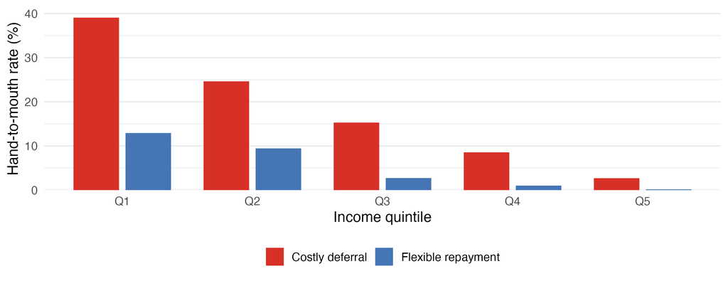

Back to main

## Appendix

### Data: mortgage amortization in the HFCS

#### % of regular payment going to amortization

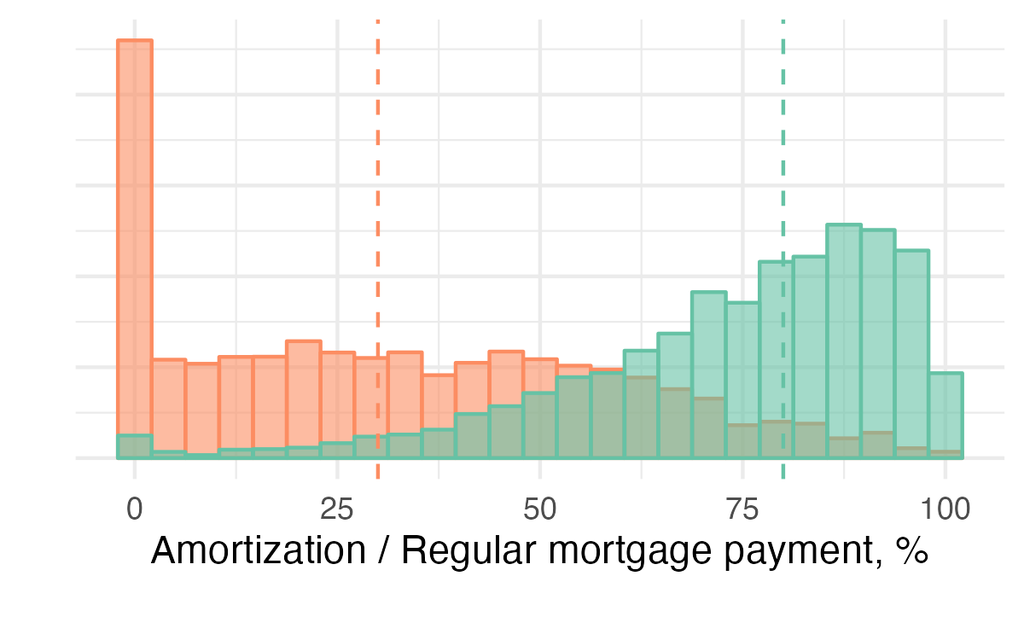

#### % of household income going to amortization

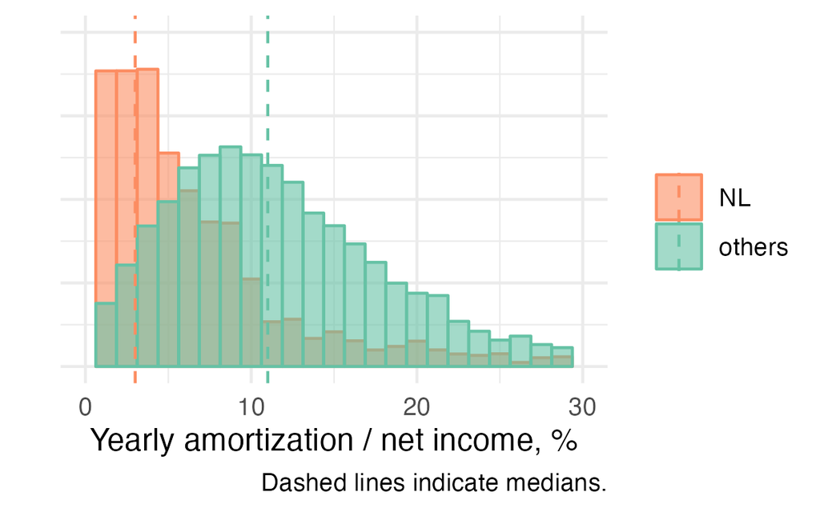

Back to main

## Appendix

### Amortization by wave

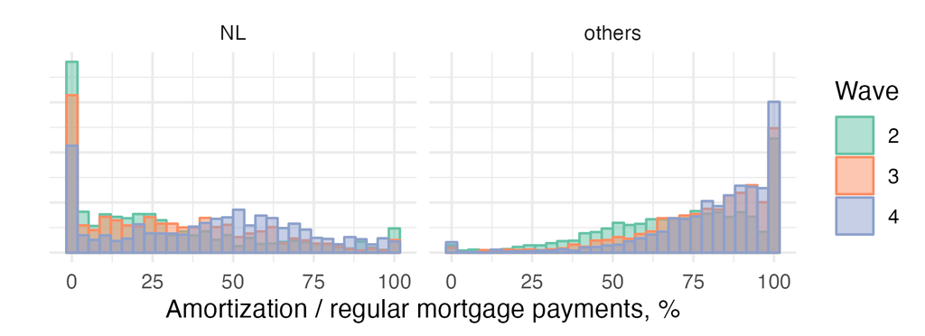

Back to main

## Appendix

### Amortization for mortgages before and after 2013

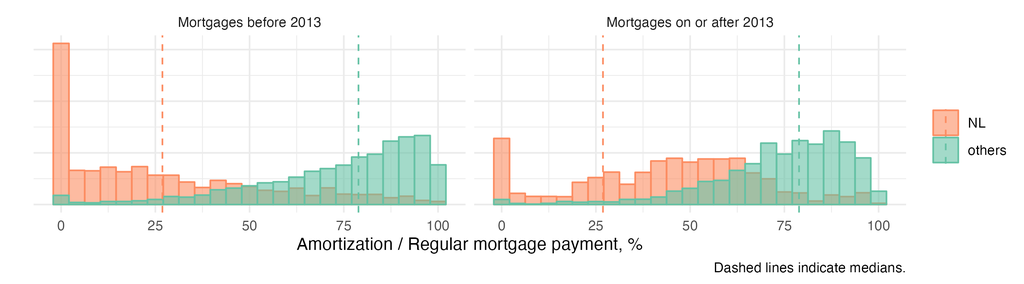

Percentage of obs. where amortization is less than 5% of the regular payment:

|  | NL | others |
| --- | --- | --- |
| Mortgages before 2013 | 30.1 | 1.7 |
| Mortgages on or after 2013 | 11.8 | 1.0 |

Back to main

## Appendix

### Interest rates

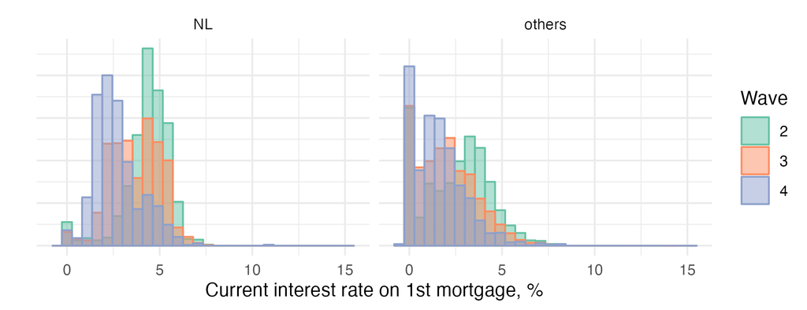

Back to main

## Appendix

### Amortization implied by annuity formula

- If mortgage is an annuitized loan, the amortization paid as part of the installment in period $t$ is:
  $$L\times r\times\left(\frac{1}{1-\frac{1}{(1+r)^{T-t}}}-1\right)$$
  - where $L$ is the outstanding amount, $r$ the loan rate and $T$ the residual maturity.
- This is what we observe for the median HH in the overall sample but not in NL:

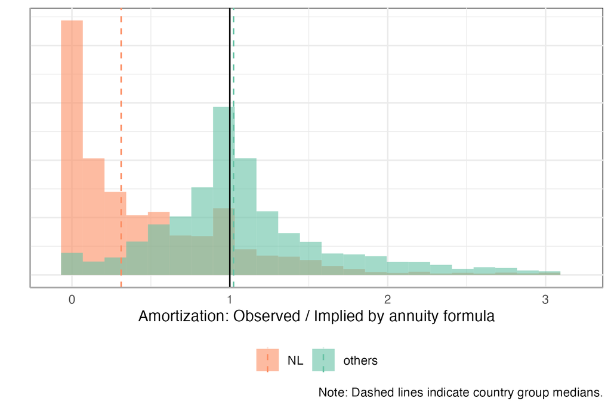

Back to main

## Appendix

### Weight of regular mortgage payments on income

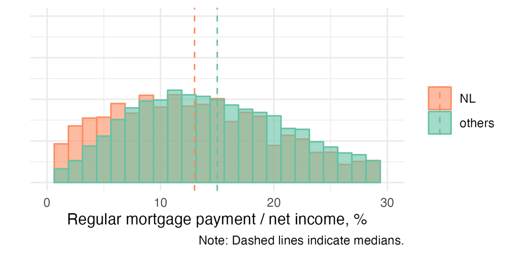

Back to main

## Appendix

### Saving rate measure checks

- Match with self-reported ability to save:

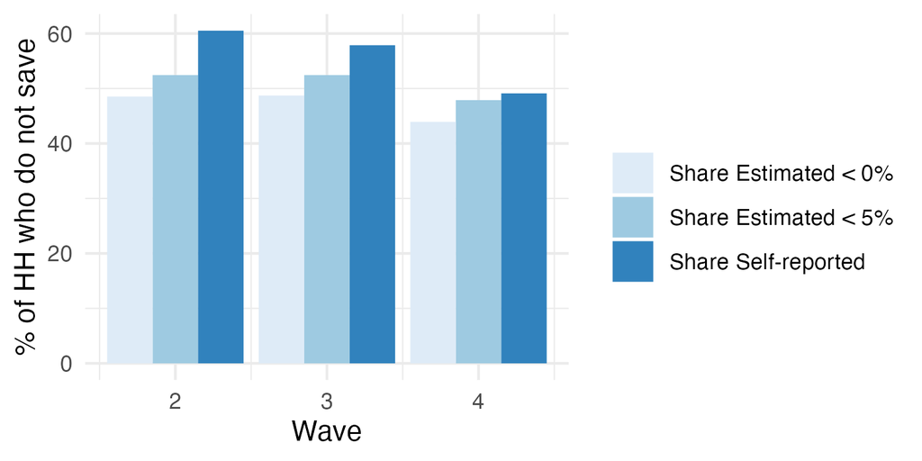

- HFCS aggregates vs. national accounts (QSA)

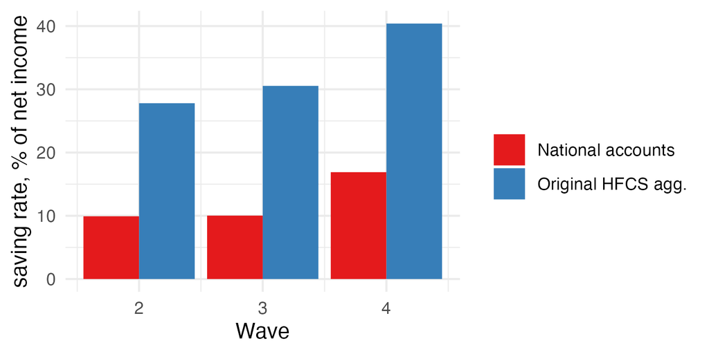

Back to main

## Appendix

### Income process

Inelastic labor supply yields earnings $Y_{t} = \Gamma_{t}Z_{t}\,\theta_{t}$, as standard (Carroll & Samwick, 1997)

- $\ln Z_{t} = \ln Z_{t-1} + \ln \psi_{t}$;  
  $\ln\psi_{t}\sim N\bigl(-\tfrac12\sigma_{\psi}^{2},\,\sigma_{\psi}^{2}\bigr)$ ; $\ln \theta_{t}\sim N\bigl(-\tfrac12\sigma_{\theta}^{2},\,\sigma_{\theta}^{2}\bigr)$
- Life‐cycle profile $\Gamma$ from HFCS
- Moments of stochastic process from NL micro data  
  (de Nardi et al. 2021)
- Two types: college vs. lower education
  - Different income levels and growth patterns
  - Different price/income ratios (but LtVs same)

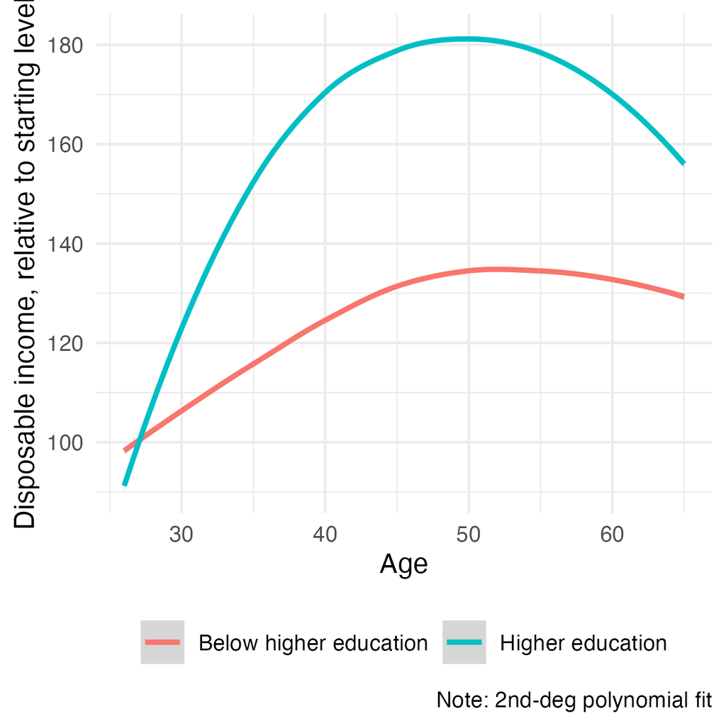

## Appendix

### Data: saving rates in the HFCS

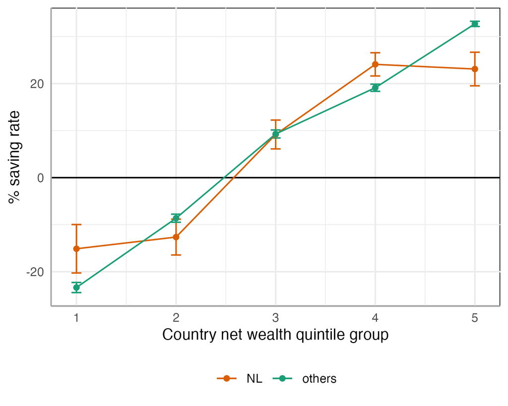

- Saving rates increase with wealth for both

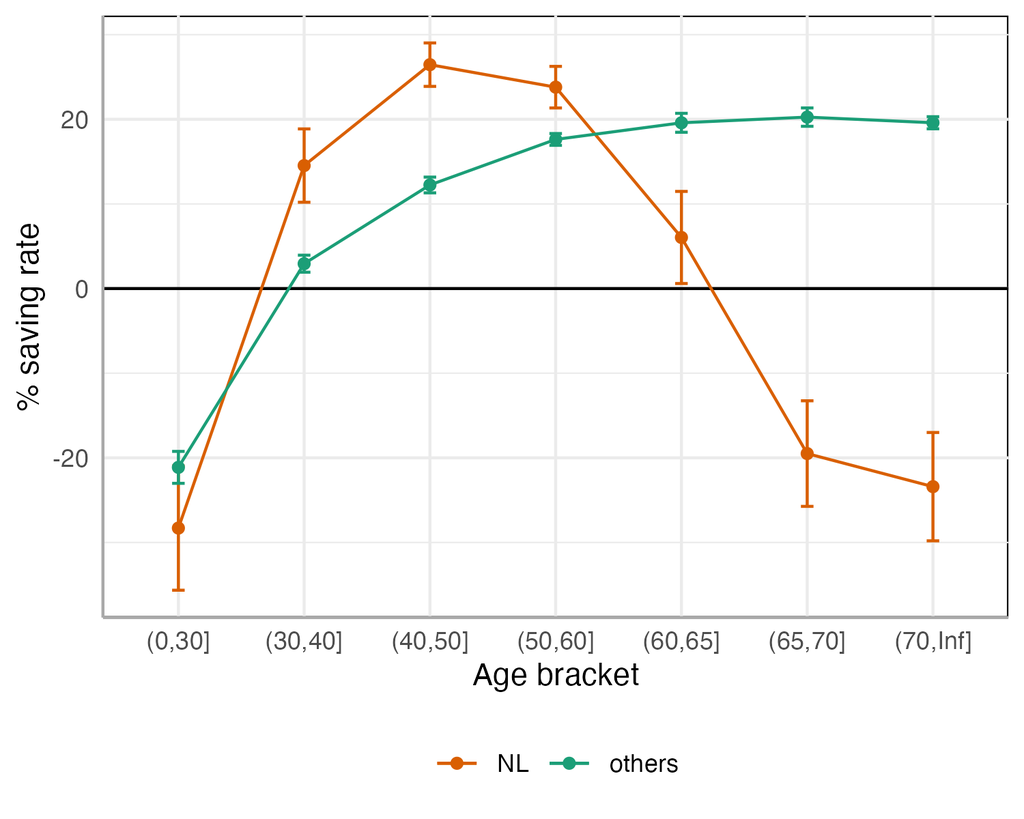

- Decline in old age in NL
- Interesting, as illiquidity of housing possible reason for plateau of saving (eg Yang 2009)

Back to main

## Appendix

### Data from Euro area countries

#### Saving rates over the wealth distribution (Q5 = 100)

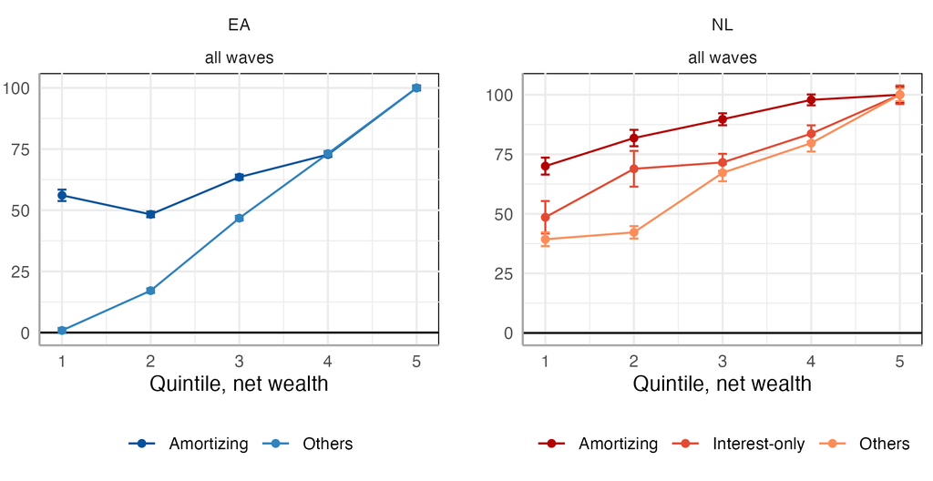

Back to main

## Appendix

### Saving rates over the wealth distribution

#### Mortgaged homeowners vs. others

- Waves 3 and 4:

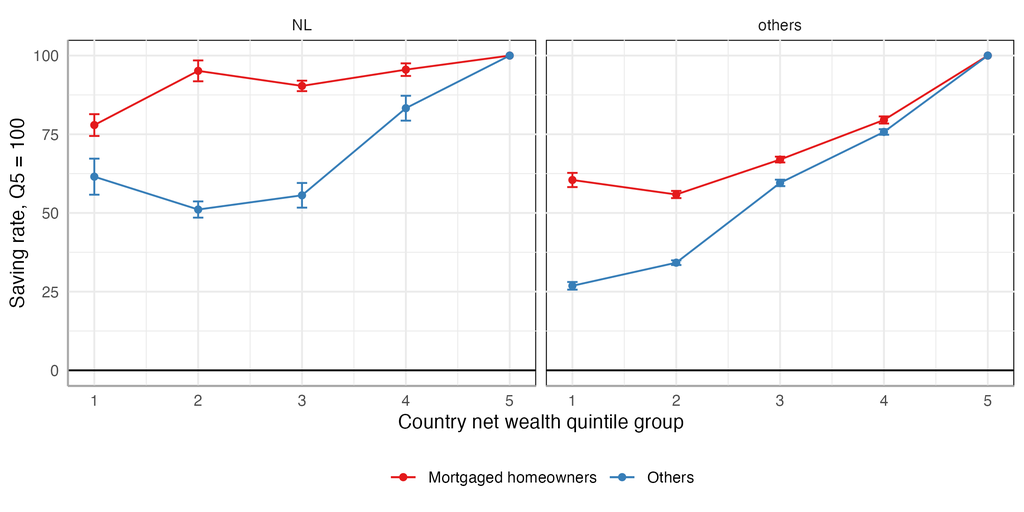

Back to main

## Appendix

### Saving rates over the wealth distribution

#### Mortgaged homeowners vs. others

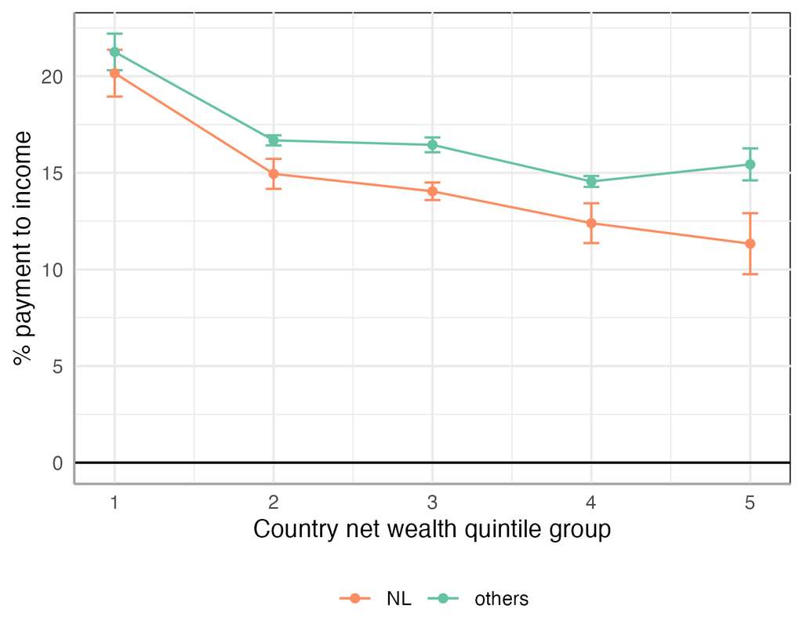

Back to main

## Appendix

### Flattening of saving rate differences reproduces pattern in the data

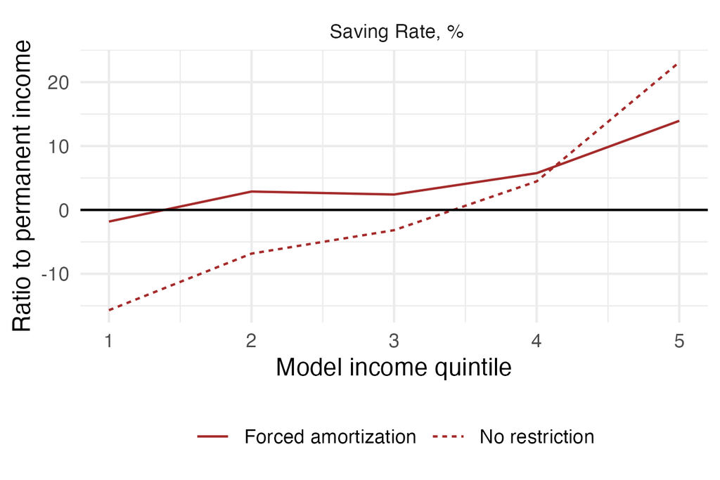

- Saving rates increase for lower income (and younger ages)

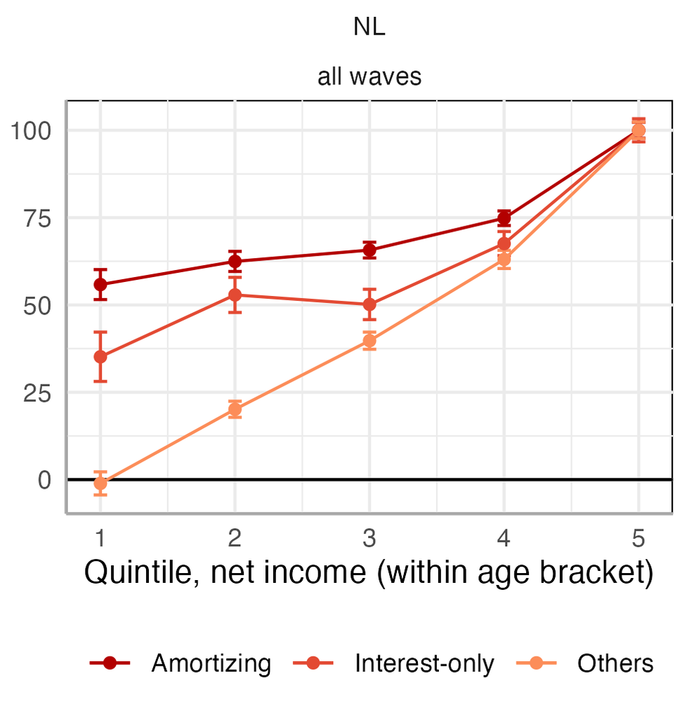

## Appendix

### Saving rates over the life cycle

#### Saving by homeowners in NL and others

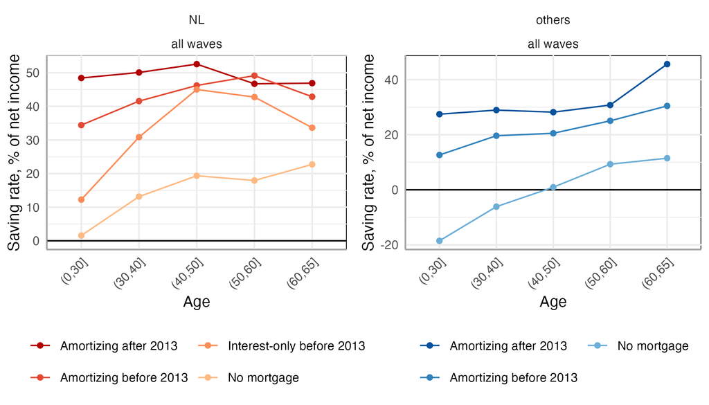

- No substantial difference between post-policy reform mortgages

Back to main

## Appendix

### Saving rates over the wealth distribution

#### Saving by homeowners in NL and others

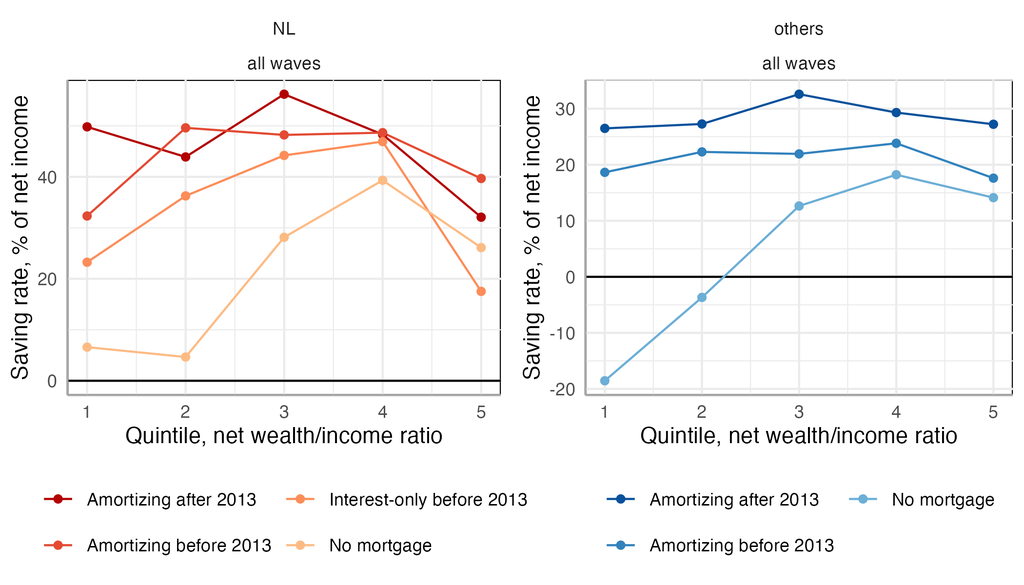

- No substantial difference between post-policy reform mortgages

Back to main

## Appendix

### Age profiles of debt in the data

- Life cycle profile of savings and mortgage debt
- Strict subsample of households who:
  - Have never refinanced
  - Live in their first home
    - Roughly identified by age at purchase $≤35$
- Interest-only mortgages: those for which amortization is $<$ 80% implied by annuity formula

## Appendix

### Age profiles of debt in the data

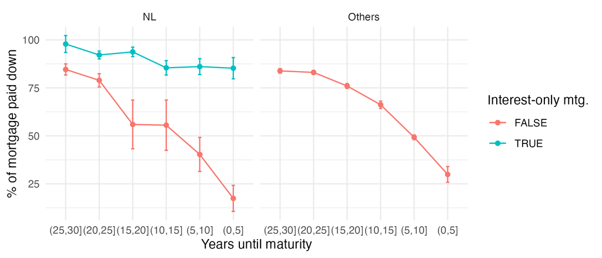